# MS Comprehensive Exam 2022

STA 207 (100 points)

**Read the instructions on Canvas carefully!**

**Name**:

**Student ID**:

```r
library(lme4)
library(ggplot2)

library(dplyr)

library(lme4)


library(ggplot2)
library(haven)

library(car)
```

In this exam, we investigate the `ChickWeight` dataset in `R`. You can load the data using the following commands. Carefully read the help file of `ChickWeight` before working on the following questions.

```r
data(ChickWeight)
df<-ChickWeight
```

**(a) Briefly summarize all variables in the data set. You need to provide the definition of the variable and quantitative summary.**

**Solution:**

There are 4 variables in this dataset:

weight: this is the chicks weight in grams

Time: This the time in days after the chick has hatched

Chick: The is a unique identifier for each chick from 1 to 50

```r
# (a). (Type your code in the space below, if any)

summary(df)
```

```
##      weight           Time           Chick     Diet
##  Min.   : 35.0   Min.   : 0.00   13     : 12   1:220
##  1st Qu.: 63.0   1st Qu.: 4.00   9      : 12   2:120
##  Median :103.0   Median :10.00   20     : 12   3:120
##  Mean   :121.8   Mean   :10.72   10     : 12   4:118
##  3rd Qu.:163.8   3rd Qu.:16.00   17     : 12
##  Max.   :373.0   Max.   :21.00   19     : 12
##                                  (Other):506
```

**(b) Visualize the weights of each chicks over time in one plot, where (i) each chick is represented by one solid curve, and (ii) the `diet` is color-coded as black (1), red (2), green (3), and blue (4). In addition to the required visualization, you may add any supporting curves, symbols, or any additional plots that you find informative.**

**Solution:** (Type your answer here)

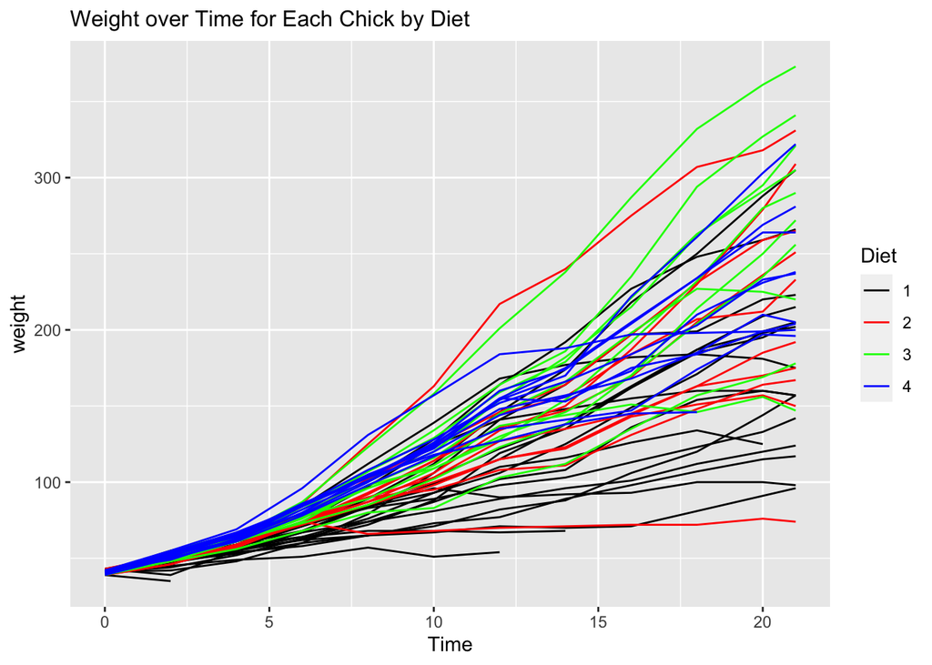

```r
# (b). (Type your code in the space below, if any)


p=ggplot(df) +
  geom_line(
    mapping = aes(x = Time, y = weight,
                  group = Chick,
                  color = Diet)
  ) +theme(legend.position = "right",plot.title = element_text(size=12))+ ggtitle("Weight over Time for Each Chick by Diet")

p+scale_color_manual(values = c("black", "red", "green","blue"))
```

**(c) Write down an appropriate one-way ANOVA model to answer the question whether there is any changes in mean weights at Day 20 across the four diet group. To receive full credits, you need to (i) write down the model, explain your notation, constraint(s) and/or assumptions; (ii) state the null and alternative hypotheses; (iii) state the test result. You can find basic LaTeX commands at the end of this file.**

**Solution:**

One Way anova model:

$$Y_{i,j}= \mu_. +\alpha_i +\epsilon_{ij}$$
i represents the 4 different diets, 1,2,3, and 4 j represents the chick

$Y_{i,j}$ represents the weight of the jth chick that had the ith diet

$\mu_.$ represent the population mean of the mean weight of the chicks in grams on day 20

$\alpha_i$ represents the added effect of the ith diet on mean weight

$\epsilon_{ij}$ is th error term

Constraints:

$\sum_i^4\alpha = 0$, $\epsilon$~N(0,$\sigma^2$)

Hypothesis Test:
$$H_0: \alpha_i =0 \space \forall i=1...4\quad\space Ha: \text{not all } \alpha_i=0$$

The p-value of the test F Test is 0.00291 which is less than 0.05 which means that at the 0.05 significance level diet has an effect on mean mean weight on day 20 from chicks.

```r
# (c). (Type your code in the space below, if any)

df_20 = df[df$Time==20,]
fit1<- aov(weight ~Diet, data= df_20)

summary(fit1)
```

```
##             Df Sum Sq Mean Sq F value  Pr(>F)
## Diet         3  55881   18627   5.464 0.00291 **
## Residuals   42 143190    3409
## ---
## Signif. codes:  0 '***' 0.001 '**' 0.01 '*' 0.05 '.' 0.1 ' ' 1
```

**(d) For the model fitted in (c), carry out necessary diagnostics to check if the model assumptions are valid. What are your findings?**

**Solution:** (Type your answer here) According to the histogram of residuals the residuals look symetrical on 0

Based on the Shaprio Wilk test there is no deviation from normality. Also according to the QQ-Plot there are not severe deviations from noramiity

Based on th Levens there is no unequal variance among the error terms. Also, the residual vs fitted shows an equal spread around 0 and no obvious trends.

Therefore, out assumption of normality holds

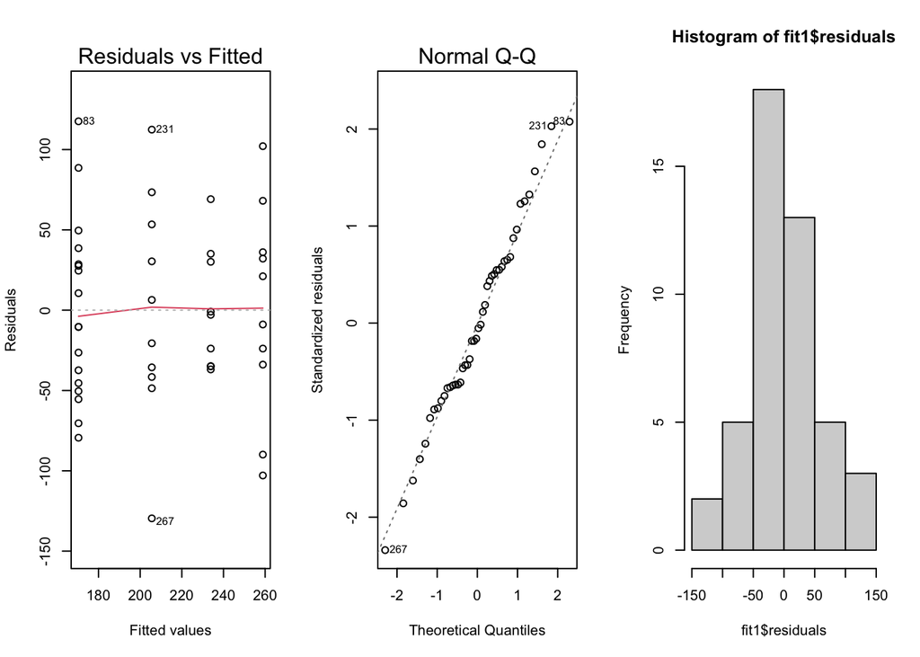

```r
# (d). (Type your code in the space below, if any)

par(mfrow=c(1,3))

plot(fit1, which =c(1,2))
hist(fit1$residuals)
```

```r
shapiro.test(x=fit1$residuals)
```

```
##
##  Shapiro-Wilk normality test
##
## data:  fit1$residuals
## W = 0.98573, p-value = 0.8378
```

```r
leveneTest(weight~Diet, data = df_20)
```

```
## Levene's Test for Homogeneity of Variance (center = median)
##       Df F value Pr(>F)
## group  3  1.1111 0.3553
##       42
```

**(e) Write down an appropriate two-way ANOVA model with fixed effect to answer the question whether there is any differences in growth rates across the four diet groups. Here the growth rate can be roughly seen as the effects of `Time` on `weight`. To receive full credits, you need to (i) write down the model, explain your notation, constraint(s) and/or assumptions; (ii) state the null and alternative hypotheses; (iii) state the test result. Hint: You may want to recycle the answer in (c) to save time.**

**Solution:** (Type your answer here)

Two Way anova model:

$Y_{i,j,k}$ represents the weight of the kth chick that had the ith diet on the jth day

$\mu_{..}$ represent the population mean of the mean weight of the chicks in grams

$\alpha_i$ represents the added effect of the ith diet on mean weight

$\beta_j$ represents the added effect of the jth day on mean weight

$(\alpha\beta)_{ij}$ represents the interaction between time and diet

$\epsilon_{ijk}$ is th error term

A F-test was conducted to test if there is a difference in growth rate across the different diets. A full model including Diet Time, and the interaction effect was test against the reduced model with no interaction effect. Based on the p-value of the test which is 3.474e-14. Therefore there are differences in growth rates across the four diet groups at the 0.05 significance level.

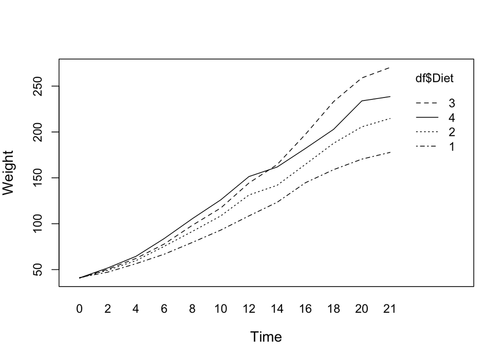

```r
# (e). (Type your code in the space below, if any)

 #Interaction plot
interaction.plot(df$Time, df$Diet, df$weight
                ,cex.lab=1.2,ylab="Weight",xlab='Time')
```

```r
fit2<-aov(weight ~Diet +Time+Diet*Time , data= df)
fit2_red<-aov(weight ~Diet+Time  , data= df)

summary(fit2)
```

```
##              Df  Sum Sq Mean Sq F value   Pr(>F)
## Diet          3  155863   51954   44.77  < 2e-16 ***
## Time          1 2016357 2016357 1737.37  < 2e-16 ***
## Diet:Time     3   80804   26935   23.21 3.47e-14 ***
## Residuals   570  661532    1161
## ---
## Signif. codes:  0 '***' 0.001 '**' 0.01 '*' 0.05 '.' 0.1 ' ' 1
```

```r
anova(fit2,fit2_red)
```

```
## Analysis of Variance Table
##
## Model 1: weight ~ Diet + Time + Diet * Time
## Model 2: weight ~ Diet + Time
##   Res.Df    RSS Df Sum of Sq      F    Pr(>F)
## 1    570 661532
## 2    573 742336 -3    -80804 23.208 3.474e-14 ***
## ---
## Signif. codes:  0 '***' 0.001 '**' 0.01 '*' 0.05 '.' 0.1 ' ' 1
```

**(f) We want to take the chick-specific effect into account. The new mixed effect model is based on the model in (e), where `Time` is treated as a continuous covariate instead of a categorical factor, and a random intercept and a random slope (of `Time`) are added into the model. Report the fitted coefficients of the fixed effects, and summarize your findings from this model. Hint: You do not need to write down the new model, but you may find it helpful.**

**Solution:** (Type your answer here)

The fixed coefficients are:

```r
# (f). (Type your code in the space below, if any)

fit.rand<-lmer(weight ~Diet +Diet:Time+(Diet|Time), data= df)
```

```
## boundary (singular) fit: see help('isSingular')
```

```r
sum_rand<-summary(fit.rand)



coef(sum_rand)
```

```
##                 Estimate Std. Error     t value
## (Intercept)  30.71511133  4.7552050  6.45926128
## Diet2        -2.08151580  7.1837124 -0.28975489
## Diet3       -12.46478611  7.8910421 -1.57961217
## Diet4         0.02849445  7.2093857  0.00395241
## Diet1:Time    6.86482356  0.3790934 18.10852956
## Diet2:Time    8.60913629  0.4955214 17.37389455
## Diet3:Time   11.42287097  0.6246739 18.28613469
## Diet4:Time    9.72229223  0.4815725 20.18863689
```

**(g) Assume that the chicks in each diet are randomly selected from the same population, i.e., the enrollment of chicks is independent from any other factors. State the Stable Unit Treatment Value Assumption, write down the potential outcomes (weight at Day 20), and verify whether the randomization assumption holds. (This question will be replaced by another, since causal inference will not be covered this quarter.)**

**Solution:** (Type your answer here)

**LaTeX commands**

$$Y_{i,j,k}, \mu, \alpha, \beta, \epsilon, i, j, H_0, H_a, \neq, =, \ldots$$